# TA

11 February, 2026

# Stanley et al. 2018

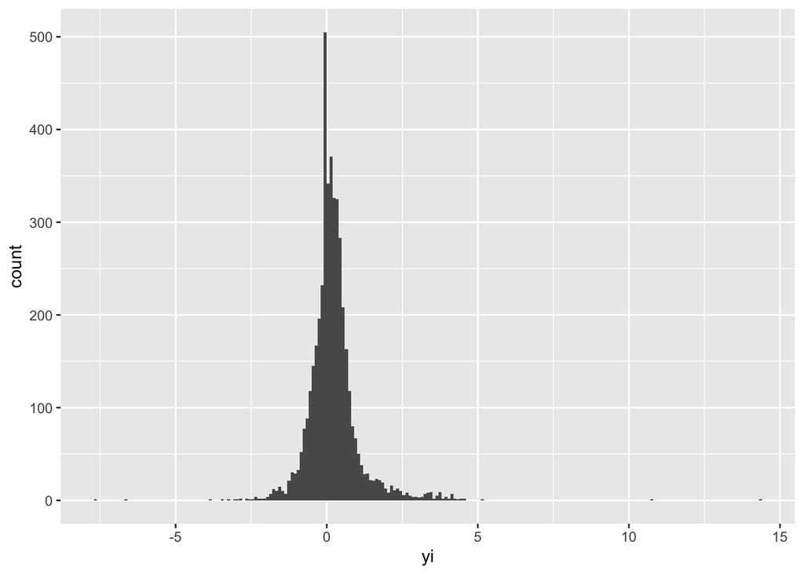

```r
library(tidyverse)
library(haven)
library(fs)

dat_raw <- dir_ls("data/", glob = "*.dta") %>%
  map_dfr(~read_dta(.x) %>% mutate(across(everything(), as.character)), .id = "source_file")

dat_cleaned <- dat_raw %>%
  mutate(
    # --- 1. Study Identifier Parsing ---
    # Handle the Authors/Year and author/date splits found in your colnames
    author_year_comp = case_when(
      !is.na(Authors) & !is.na(Year) ~ paste0(Authors, " (", Year, ")"),
      !is.na(author) & !is.na(date) ~ paste0(author, " (", date, ")"),
      TRUE ~ NA_character_
    ),

    # Coalesce every possible study name variant (including the 'strudy' typo)
    study_id = coalesce(
      Studyname,
      AuthorYearofpublication,
      Citation,
      author_year_comp,
      Study,
      study,
      strudy, # Typo at index 267
      Authors,
      Author,
      author,
      id,
      ID
    ),

    # --- 2. Effect Size (yi) ---
    yi = as.numeric(coalesce(
      r, correlation, d, g, es, fischer, z, averager, dreportedinpaper
    )),

    # --- 3. Sample Size (ni) ---
    # Sum group Ns if total N is missing (e.g., N1 + N2 or Nf + Nm)
    n_sum_groups = as.numeric(N1) + as.numeric(N2),
    n_sum_gender = as.numeric(Nf) + as.numeric(Nm),
    n_sum_control = as.numeric(Nc) + as.numeric(Ne),

    ni = coalesce(
      as.numeric(N), as.numeric(n), as.numeric(totalN), as.numeric(samplesize),
      n_sum_groups, n_sum_gender, n_sum_control
    ),

    # --- 4. Standard Error (sei) ---
    sei = case_when(
      !is.na(SE) ~ as.numeric(SE),
      !is.na(se) ~ as.numeric(se),
      !is.na(sed) ~ as.numeric(sed),
      !is.na(SEd) ~ as.numeric(SEd),
      !is.na(sefischer) ~ as.numeric(sefischer),
      !is.na(SEused) ~ as.numeric(SEused),
      !is.na(variance) ~ sqrt(as.numeric(variance)),
      !is.na(Variance) ~ sqrt(as.numeric(Variance)),
      TRUE ~ NA_real_
    ),

    # --- 5. Metric Classification ---
    metric = case_when(
      !is.na(r) | !is.na(correlation) | !is.na(fischer) ~ "r",
      !is.na(d) | !is.na(g) | !is.na(dreportedinpaper) ~ "d",
      TRUE ~ NA_character_
    )
  ) %>%
  # File-level heuristic to catch files using only 'es'
  group_by(source_file) %>%
  mutate(
    metric = case_when(
      !is.na(metric) ~ metric,
      max(abs(as.numeric(es)), na.rm = TRUE) > 1.05 ~ "d",
      TRUE ~ "r"
    )
  ) %>%
  ungroup() %>%
  # --- Final Selection and Sanitization ---
  #filter(!is.na(yi)) %>%
  select(
    source_file,
    study_id,
    yi,
    sei,
    ni,
    metric,
    #everything() # Keep moderators for later meta-regressions
  )

# 3. Split by metric
dat_r <- dat_cleaned %>% filter(metric == "r")
dat_d <- dat_cleaned %>% filter(metric == "d")

# dat |>
#   count(!is.na(study1), !is.na(study2), !is.na(study3), !is.na(study4), !is.na(study5))
#
# dat |>
#   count(!is.na(es), !is.na(averager), !is.na(Hedgessg), !is.na(correlation))


ggplot(dat_d, aes(yi)) +
  geom_histogram(boundary = 0, binwidth = 0.1)
```

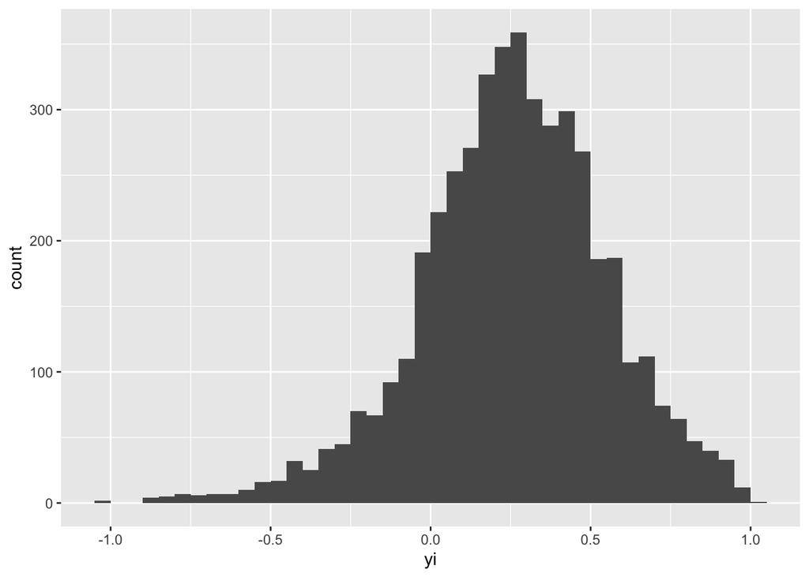

```r
ggplot(dat_r, aes(yi)) +
  geom_histogram(boundary = 0, binwidth = 0.05)
```

```r
percentile_probs <- c(.01, seq(.05, .95, by = 0.05), .96, .97, .98, .99, .999, .9999)

# 2. Summarize percentiles for Correlations (r)
percentiles_r <- dat_r %>%
  reframe(
    percentile = paste0(percentile_probs * 100, "%"),
    r_raw = quantile(yi, probs = percentile_probs, na.rm = TRUE),
    r_abs = quantile(abs(yi), probs = percentile_probs, na.rm = TRUE)
  )

# 3. Summarize percentiles for Standardized Mean Differences (d)
percentiles_d <- dat_d %>%
  reframe(
    percentile = paste0(percentile_probs * 100, "%"),
    d_raw = quantile(yi, probs = percentile_probs, na.rm = TRUE),
    d_abs = quantile(abs(yi), probs = percentile_probs, na.rm = TRUE)
  )

# 4. Optional: Combine for a side-by-side comparison table
percentile_comparison <- left_join(percentiles_r, percentiles_d, by = "percentile")

print(percentile_comparison)
```

```
## # A tibble: 26 × 5
##    percentile r_raw r_abs   d_raw  d_abs
##    <chr>      <dbl> <dbl>   <dbl>  <dbl>
##  1 1%         -0.55  0    -1.7    0
##  2 5%         -0.24  0.03 -0.852  0
##  3 10%        -0.09  0.06 -0.57   0.0368
##  4 15%        -0.01  0.09 -0.4    0.07
##  5 20%         0.04  0.12 -0.27   0.11
##  6 25%         0.09  0.15 -0.15   0.14
##  7 30%         0.13  0.18 -0.0697 0.18
##  8 35%         0.17  0.21  0      0.22
##  9 40%         0.2   0.24  0.01   0.269
## 10 45%         0.24  0.27  0.0784 0.31
## # ℹ 16 more rows
```

```r
temp <- dat_d |>
  mutate(abs_yi = abs(yi))
```

# Spot checks of original studies included in Harkin et al. 2016

This meta-analysis reports at least 18 effect sizes that are larger than Cohen’s d of 4, which are in the top 1% of Cohen’s d effect sizes reported in contemporary psychology meta-analyses by [Stanley et al. (2018)](https://doi.org/10.1037/bul0000169). Harkin et al.’s (2016) are included in Stanley et al., which is how I became aware of them.

Given that this study extracts its data from psychological studies on various health interventions and related studies, there is no reason to believe that it’s included effect sizes should be so exceptionally large. I therefore performed spot checks to try to reproduce some of the largest effects included in the meta-analysis.

## Numbers from Tan et al. (2011)

Harkin et al. includes Tan et al. (2011) as d = 14.46.

```r
library(tidyverse)
library(roundwork)

calculate_d_from_ci <- function(m1, l1, u1, m2, l2, u2, n1, n2) {
  t_crit1 <- qt(0.975, df = n1 - 1)
  t_crit2 <- qt(0.975, df = n2 - 1)

  # CI width to SD
  sd1 <- ((u1 - l1) / (2 * t_crit1)) * sqrt(n1)
  sd2 <- ((u2 - l2) / (2 * t_crit2)) * sqrt(n2)

  # pooled SD
  sd_pooled <- sqrt(((n1 - 1) * sd1^2 + (n2 - 1) * sd2^2) / (n1 + n2 - 2))

  # Cohen's d
  return((m1 - m2) / sd_pooled)
}

d_result <- calculate_d_from_ci(
  m1 = 2.88, l1 = 2.53, u1 = 3.23, # Intervention
  m2 = 0.62, l2 = 0.35, u2 = 0.89, # Control
  n1 = 82,   n2 = 82               # N per group
)
```

Recalculated d = 1.59

The result included Harkin et al. seems to be a result of treating the SD as if it is an SE, despite it being reported as an SD:

```r
calculate_mistaken_d <- function(m1, l1, u1, m2, l2, u2) {
  # 1. Mistakenly derive SE from CI width using the common "divide by 4" heuristic
  # (Assuming width = 4 * SE, although 1.96*2 would be more common)
  se1 <- (u1 - l1) / 4
  se2 <- (u2 - l2) / 4

  # 2. Mistakenly pool these SEs as if they were SDs
  se_pooled <- sqrt((se1^2 + se2^2) / 2)

  # 3. Calculate d using the SE in the denominator
  mistaken_d <- (m1 - m2) / se_pooled

  return(mistaken_d)
}

mistaken_result <- calculate_mistaken_d(
  m1 = 2.88, l1 = 2.53, u1 = 3.23, # Intervention
  m2 = 0.62, l2 = 0.35, u2 = 0.89  # Control
)
```

Recalculated d mistaking SD for SE = 14.46.

## Numbers from An et al. 2006

Harkin et al. includes An et al. (2006) as d = 10.72.

```r
library(effectsize)

# 1. Calculate the Odds Ratio manually
# (41/216) / (2/45) = 4.27
or_val <- (41/216) / (2/45)

# 2. Convert OR to Cohen's d
# Using the Cox method (default)
d_val <- oddsratio_to_d(or_val, log = FALSE)
```

Recalculated d = 0.8

## Numbers from Kroenke et al. 2010

Harkin et al. includes Kroenke et al. (2010) as d = 4.50. Its unclear if the depression variable was used at the 6 or 12 month time point, so I recalculate both.

```r
library(metafor)

# depression 6 months
escalc(measure = "SMD",
       m1i = 1.31,
       sd1i = 0.73,
       n1i = 113,
       m2i = 1.01,
       sd2i = 0.59,
       n2i = 110)
```

```
##
##       yi     vi
## 1 0.4498 0.0184
```

```r
# depression 12 months
escalc(measure = "SMD",
       m1i = 1.32,
       sd1i = 0.83,
       n1i = 105,
       m2i = 1.06,
       sd2i = 0.65,
       n2i = 98)
```

```
##
##       yi     vi
## 1 0.3460 0.0200
```

Neither match, Cohen’s d from .35 to .45.

Given these spot checks all failing to reproduce those included in the meta-analysis, and the implausibility of many of these very large effect sizes above 3 and 4, could authors comment on the accuracy of the extracted effect sizes and on the results of the meta-analysis?

```r
# pain 6 months
escalc(measure = "SMD",
       m1i = 4.38,
       sd1i = 2.21,
       n1i = 103,
       m2i = 3.55,
       sd2i = 2.36,
       n2i = 103)
```

```
##
##       yi     vi
## 1 0.3617 0.0197
```

```r
# pain 12 months
escalc(measure = "SMD",
       m1i = 4.33,
       sd1i = 2.21,
       n1i = 89,
       m2i = 3.62,
       sd2i = 2.42,
       n2i = 91)
```

```
##
##       yi     vi
## 1 0.3049 0.0225
```